# India’s Alcohol Consumption and Women Empowerment

Luke Wolcott

May 6, 2017

A mid-April [New York Times article](https://www.nytimes.com/2017/04/15/world/asia/india-bihar-alcohol-ban-women.html?_r=0) describes how the Indian state of Bihar recently enacted a prohibition law, with positive results. Most interestingly, the driving force was organized activism by village women.

Separately, India’s 4th National Family Health Survey was recently completed (2015-2016, 700k respondents) and the data made available by the [DHS (Demographic and Health Surveys) Program](http://rchiips.org/nfhs/data1.shtml).

There’s a summary of the NFHS’s India-wide findings here:

http://rchiips.org/nfhs/pdf/NFHS4/India.pdf

This survey asks many family health questions, including asking what percentage of men and women consume alcohol. Nationally, 29.2% of men, and 1.2% of women, report consuming alcohol.

It asks 8 questions related to women’s empowerment. Using this, the Hindustan Times (HT) created a “Women Empowerment Index” and [ranked each state and union territory](https://github.com/HindustanTimesLabs/women-empowerment-index).

My question: **Is there a relationship between the amount of male alcohol consumption, and the HT’s Women Empowerment Index?**

Does Bihar stand out, in terms of alcohol and women’s empowerment, or might other states follow suit?

### Dataset

The NFHS data [was released](http://rchiips.org/nfhs/pdf/NFHS4/India.pdf) in a few dozen different PDF files. I manually scraped the male and female alcohol consumption data, and combined it with the HT’s Women Empowerment Index. I also added a factor variable indicating each state or union territory’s region within India. This CSV file is in the Github repo corresponding to this report.

### Male Alcohol Consumption versus Women Empowerment

[interactive chart not shown]

This plotly graph shows that there is a positive correlation between male alcohol consumption and women’s empowerment. The state of Bihar, where women organized to make alcohol illegal, actually has the lowest empowerment index (0.14) of any state!

The correlation coefficient is `0.3895287`. A linear fit gives the following coefficients and p-values.

```
##                         Estimate Std. Error  t value    Pr(>|t|)
## (Intercept)             20.12025   6.872202 2.927773 0.006051707
## HTWomenEmpowermentIndex 39.45456  15.998698 2.466111 0.018859666
```

### Different regions in India

Here’s the same plot, but colored by the region of India.

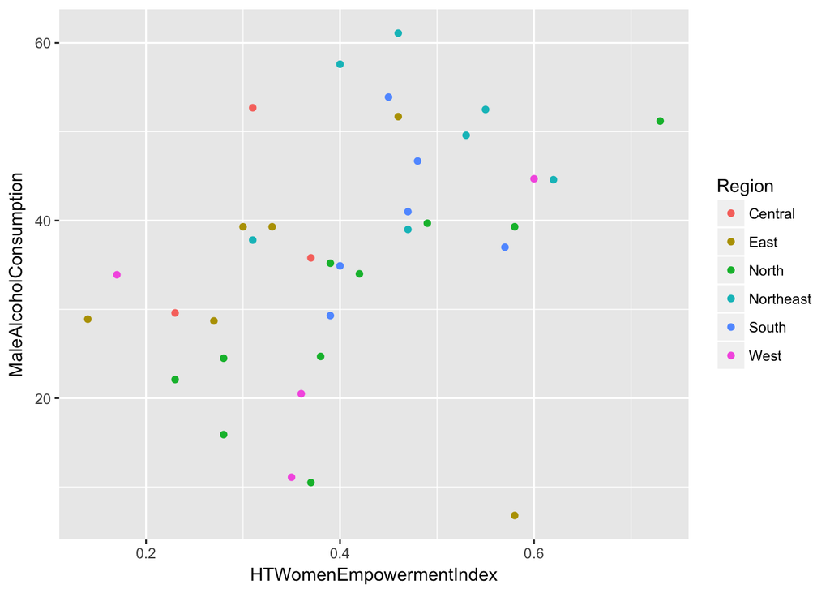

Besides noticing that the northeast states/UTs have lots of drinking, I don’t see any significant trends.